# Project 1

For your first project you are going to go through each of the following functions and optimize in terms of memory and speed. You can import any libraries and perform any code transformations but the end result must be equal in order to be correct.

I recommend that you create a separate notebook or open an IDE and experiment there. Then come back to this notebook and write your answer. Each function has a cell with the original function, another one for your solution, and a profiling and correctness checker. The final submission will be this notebook plus a consecutive run in your PC (restart, run all and save as html) and another run on your Jetson Nano. You will submit all three files on Canvas.

The first cell is used to import the libraries we need to run these functions, the second cell will be for your libraries

```python
import sys
print(sys.version)
```

```
3.8.0 (default, Dec  9 2021, 17:53:27)
[GCC 8.4.0]
```

```python
import numpy as np
import ctypes
import math
import time
from scipy import misc,ndimage
import matplotlib.pyplot as plt
from PIL import Image
# %pip install numpy==2.1
from numba import jit,prange
import requests
from io import BytesIO
# %pip install opencv-python
# %pip install memory_profiler
import cv2
%load_ext memory_profiler
```

```python
#### Import your libraries here
```

```python
url1="http://getwallpapers.com/wallpaper/full/c/a/7/1235918-3000-x-3000-hd-wallpapers-3000x2000-for-hd-1080p.jpg"
url2="http://getwallpapers.com/wallpaper/full/c/4/1/1235927-3000-x-3000-hd-wallpapers-3000x2000-screen.jpg"
response1 = requests.get(url1)
response2 = requests.get(url2)

### These will be used as input arrays, they are all images transformed to numpy arrays
#A = Image.open('nature.jpg')
# convert image to numpy array
A = Image.open(BytesIO(response1.content))
A = np.asarray(A)/255
A = np.mean(A, axis=2)*255

#B = Image.open('sun.jpg')
# convert image to numpy array
B = Image.open(BytesIO(response2.content))
B = np.asarray(B)/255
B = np.mean(B, axis=2)*255
C=np.random.rand(A.shape[0],A.shape[1])*255
```

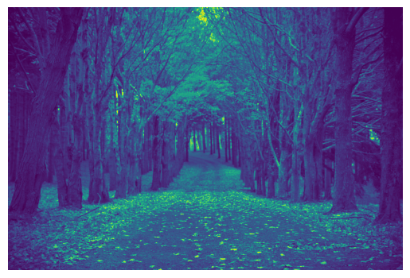

```python
### Verify the images are there and they are grayscale

plt.axis('off')
plt.imshow(A)
plt.show()
```

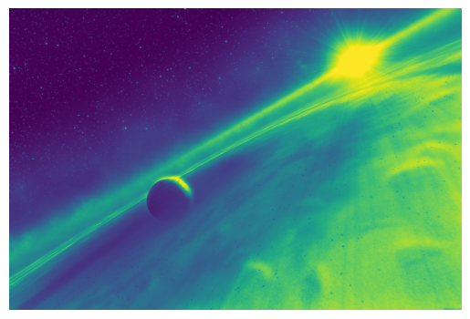

```python
plt.axis('off')
plt.imshow(B)
plt.show()
```

## Loop 1

```python
def loop1(A,B):
    a=np.copy(A)
    b=np.copy(B)

    for j in range (1,a.shape[0]-1):
        for i in range (1,a.shape[1]-1):
            a[j,i] = a[j - 1,i] + b[j,i];
            b[j,i] = b[j,i]**2

    return a,b
```

```python
x,y=loop1(A,B)
```

```python
%%timeit
loop1(A,B)
```

```
16.1 s ± 128 ms per loop (mean ± std. dev. of 7 runs, 1 loop each)
```

```python
%memit loop1(A,B)
```

```
peak memory: 687.06 MiB, increment: 91.55 MiB
```

```python
## just using numba here
@jit(nopython=True)
def loop1_sol1(A,B):
    a=np.copy(A)
    b=np.copy(B)

    for j in range (1,a.shape[0]-1):
        for i in range (1,a.shape[1]-1):
            a[j,i] = a[j - 1,i] + b[j,i];
            b[j,i] = b[j,i]**2

#     for j in range (1, a.shape[0]-1):
#             a[j,1:-1] = a[j - 1,1:-1] + b[j,1:-1]
#     b[1:-1, 1:-1] = b[1:-1, 1:-1]**2

    return a,b
```

```python
x1,y1=loop1_sol1(A,B)
```

```python
%%timeit
loop1_sol1(A,B)
```

```
74 ms ± 284 µs per loop (mean ± std. dev. of 7 runs, 10 loops each)
```

```python
%memit loop1_sol1(A,B)
```

```
peak memory: 596.03 MiB, increment: 0.43 MiB
```

```python
# ## custom here
# # @jit(nopython=True)
def loop1_sol2(A,B):
  a=np.copy(A)
  b=np.copy(B)

#     for j in range (1,a.shape[0]-1):
#         for i in range (1,a.shape[1]-1):
#             a[j,i] = a[j - 1,i] + b[j,i];
#             b[j,i] = b[j,i]**2

  for j in range (1, a.shape[0]-1):
          a[j,1:-1] = a[j - 1,1:-1] + b[j,1:-1]
          b[j,1:-1] = b[j, 1:-1]**2


  return a,b
```

```python
x2,y2=loop1_sol2(A,B)
```

```python
%%timeit
loop1_sol2(A,B)
```

```
138 ms ± 928 µs per loop (mean ± std. dev. of 7 runs, 10 loops each)
```

```python
%memit loop1_sol2(A,B)
```

```
peak memory: 778.70 MiB, increment: 91.44 MiB
```

```python
##### If output is false, then your solution is incorrect

print(np.allclose(x,x1))
print(np.allclose(y,y1))
print(np.allclose(x,x2))
print(np.allclose(y,y2))
```

```
True
True
True
True
```

```python
##### Cleanup, get rid of all the objects we don't need anymore
del x,y,x1,y1,x2,y2
```

## Loop 2

```python
def loop2(A, B, C):
    a=np.copy(A)
    b=np.copy(B)


    for j in range (1,a.shape[0]-1):
        for i in range (1,a.shape[1]-1):
            a[j][i] = a[j-1][i] + C[j][i]
        for i in range (1,b.shape[1]-1):
            b[j][i] = b[j][i-1] + C[j][i]


    return a, b
```

```python
x,y = loop2(A,B,C)
```

```python
%%timeit
loop2(A,B,C)
```

```
30.1 s ± 118 ms per loop (mean ± std. dev. of 7 runs, 1 loop each)
```

```python
%memit loop2(A,B,C)
```

```
peak memory: 595.51 MiB, increment: 91.35 MiB
```

```python
@jit(nopython=True)
def loop2_sol1(A, B, C):
    a=np.copy(A)
    b=np.copy(B)


    for j in range (1,a.shape[0]-1):
        for i in range (1,a.shape[1]-1):
            a[j][i] = a[j-1][i] + C[j][i]
        for i in range (1,b.shape[1]-1):
            b[j][i] = b[j][i-1] + C[j][i]



    return a, b
```

```python
x1,y1=loop2_sol1(A,B,C)
```

```python
%%timeit
loop2_sol1(A,B,C)
```

```
93.2 ms ± 172 µs per loop (mean ± std. dev. of 7 runs, 10 loops each)
```

```python
%memit loop2_sol1(A,B,C)
```

```
peak memory: 596.46 MiB, increment: 0.40 MiB
```

```python
def loop2_sol2(A, B, C):
    a=np.copy(A)
    b=np.copy(B)


    # for j in range (1,a.shape[0]-1):
    #     for i in range (1,a.shape[1]-1):
    #         a[j][i] = a[j-1][i] + C[j][i]
    #     for i in range (1,b.shape[1]-1):
    #         b[j][i] = b[j][i-1] + C[j][i]
    m = a.shape[0]-1
    n = a.shape[1]-1
    for j in range(1, a.shape[0]-1):
        a[j, 1:n] = a[j-1, 1:n] + C[j, 1:n]
    for i in range (1, b.shape[1]-1):
        b[1:m,i] = b[1:m, i-1] + C[1:m, i]



    return a, b
```

```python
x2,y2=loop2_sol2(A,B,C)
```

```python
%%timeit
loop2_sol2(A,B,C)
```

```
337 ms ± 114 ms per loop (mean ± std. dev. of 7 runs, 1 loop each)
```

```python
%memit loop2_sol2(A,B,C)
```

```
peak memory: 779.11 MiB, increment: 91.48 MiB
```

```python
##### If output is false, then your solution is incorrect
print(np.allclose(x,x1))
print(np.allclose(y,y1))
print(np.allclose(x,x2))
print(np.allclose(y,y2))
```

```
True
True
True
True
```

```python
##### Cleanup, get rid of all the objects we don't need anymore
del x,y,x1,y1,x2,y2
```

## Matrix multiplication

```python
# SGEMM Form => C := alpha*A*B + beta*C,
# We create new variable because the images are too big
Am=np.random.rand(100,500)
Bm=np.random.rand(500,250)
Dm=np.random.rand(100,250)
# alpha and beta are constant floating point values, reuse them for your solution
alpha = 1.5
beta = 1.2

def sgemm_manual (alpha,A, B, beta, D):

    d=np.copy(D)
    for i in range(d.shape[0]):
        for j in range(d.shape[1]):
            d[i,j] *= beta
        for k in range(A.shape[1]):
            for j in range(d.shape[1]):
                d[i,j] += alpha * A[i,k] * B[k,j]
    return d
```

```python
x=sgemm_manual (alpha,Am, Bm, beta, Dm)
```

```python
%%timeit
sgemm_manual (alpha,Am, Bm, beta, Dm)
```

```
27 s ± 285 ms per loop (mean ± std. dev. of 7 runs, 1 loop each)
```

```python
%mprun sgemm_manual (alpha,Am, Bm, beta, Dm)
```

[output not shown]

```python
@jit(nopython=True)
def sgemm_solution (alpha,A, B, beta, D):
    d=np.copy(D)
    for i in range(d.shape[0]):
        for j in range(d.shape[1]):
            d[i,j] *= beta
        for k in range(A.shape[1]):
            for j in range(d.shape[1]):
                d[i,j] += alpha * A[i,k] * B[k,j]
    return d
```

```python
x1=sgemm_solution (alpha,Am, Bm, beta, Dm)
```

```python
%%timeit
sgemm_solution (alpha,Am, Bm, beta, Dm)
```

```
20.5 ms ± 367 µs per loop (mean ± std. dev. of 7 runs, 10 loops each)
```

```python
%memit sgemm_solution (alpha,Am, Bm, beta, Dm)
```

```
peak memory: 413.31 MiB, increment: 0.00 MiB
```

```python
def sgemm_solution2 (alpha,A, B, beta, D):
    d=np.copy(D)
    #for i in range(d.shape[0]):
        # for j in range(d.shape[1]):
        #     d[i,j] *= beta
        # for k in range(A.shape[1]):
        #     for j in range(d.shape[1]):
        #         d[i,j] += alpha * A[i,k] * B[k,j]
    # d = beta * d + alpha * np.dot(A,B)
    m, n = d.shape
    o = A.shape[1]

    for i in range(m):
        d[i,:n] *=beta
        # for k in range(A.shape[1]):
        d[i:n] += alpha * np.dot(A[i,:], B)
        #     d[i,:n] += alpha * A[i,k] * B[k,:n]
    return d
```

```python
x1=sgemm_solution2(alpha,Am, Bm, beta, Dm)
```

```python
%%timeit
sgemm_solution2 (alpha,Am, Bm, beta, Dm)
```

```
29.6 ms ± 1.53 ms per loop (mean ± std. dev. of 7 runs, 10 loops each)
```

```python
%memit sgemm_solution2 (alpha,Am, Bm, beta, Dm)
```

```
peak memory: 413.38 MiB, increment: 0.00 MiB
```

```python
def optimizedsgemm(alpha, A, B, beta, d):
    m, n = d.shape
    o = A.shape[1]  # The number of columns in A (also the number of rows in B)

    # Multiply each row of d by beta (this can be done directly)
    d[:, :n] *= beta

    # Perform the matrix operation
    d[:, :n] += alpha * (A @ B[:, :n])  # Matrix multiplication

    return d
```

```python
x2=optimizedsgemm (alpha,Am, Bm, beta, Dm)
```

```python
%%timeit
optimizedsgemm (alpha,Am, Bm, beta, Dm)
```

```
2.39 ms ± 166 µs per loop (mean ± std. dev. of 7 runs, 100 loops each)
```

```python
##### If output is false, then your solution is incorrect
print(np.allclose(x,x1))
print(np.allclose(x,x2))
```

```
False
False
```

```python
##### Cleanup, get rid of all the objects we don't need anymore
del x,x1, x2
```

## Laplacian operator

```python
def Laplacian_Operator(A):
    x = A.shape[0]
    y = A.shape[1]
    laplacian = np.empty((x - 2, y - 2))
    for i in range(1, x - 1):
        for j in range(1, y - 1):
            laplacian[i-1, j-1] = np.abs(A[i-1, j] + A[i+1, j] + A[i, j-1] + A[i, j+1] - 4*A[i, j]) > 0.05
    return laplacian
```

```python
LO=Laplacian_Operator(A)
```

```python
%%timeit
Laplacian_Operator(A)
```

```
1min 11s ± 404 ms per loop (mean ± std. dev. of 7 runs, 1 loop each)
```

```python
%memit Laplacian_Operator(A)
```

```
peak memory: 504.74 MiB, increment: 45.59 MiB
```

```python
def Laplacian_Operator_Sol(A):

    # x = A.shape[0]
    # y = A.shape[1]
    # laplacian = np.empty((x - 2, y - 2))
    # # laplacian[0:x-2, 0:y-2] = np.abs(A[0:x-2, 1:y-1] + A[2:x, 1:y-1] + A[1:x-1, 0:y-2] + A[1:x-1, 2:y] - 4*A[1:x-1, 1:y-1]) > 0.05

    # for i in range(1, x - 1):
    #     laplacian[i-1, 0:y-2] = np.abs(A[i-1, 1:y-1] + A[i+1, 1:y-1] + A[i, 0:y-2] + A[i, 2:y] - 4*A[i, 1:y-1]) > 0.05
    #     # for j in range(1, y - 1):
    #     #     laplacian[i-1, j-1] = np.abs(A[i-1, j] + A[i+1, j] + A[i, j-1] + A[i, j+1] - 4*A[i, j]) > 0.05

    laplacian = np.abs(
        A[:-2, 1:-1] +  # Top neighbor
        A[2:, 1:-1] +   # Bottom neighbor
        A[1:-1, :-2] +  # Left neighbor
        A[1:-1, 2:] -   # Right neighbor
        4 * A[1:-1, 1:-1]  # Center pixel
    ) > 0.05  # Apply threshold condition

    return laplacian
```

```python
@jit(nopython=True)
def Laplacian_Operator_Numba(A):
    x = A.shape[0]
    y = A.shape[1]
    laplacian = np.empty((x - 2, y - 2))
    for i in range(1, x - 1):
        for j in range(1, y - 1):
            laplacian[i-1, j-1] = np.abs(A[i-1, j] + A[i+1, j] + A[i, j-1] + A[i, j+1] - 4*A[i, j]) > 0.05
    return laplacian


    return laplacian
```

```python
SO=Laplacian_Operator_Sol(A)
```

```python
NO=Laplacian_Operator_Numba(A)
```

```python
%%timeit
Laplacian_Operator_Sol(A)
```

```
212 ms ± 1.39 ms per loop (mean ± std. dev. of 7 runs, 1 loop each)
```

```python
%%timeit
Laplacian_Operator_Numba(A)
```

```
56.9 ms ± 78.1 µs per loop (mean ± std. dev. of 7 runs, 10 loops each)
```

```python
%memit Laplacian_Operator_Sol(A)
```

```
peak memory: 594.02 MiB, increment: 88.99 MiB
```

```python
%memit Laplacian_Operator_Numba(A)
```

```
peak memory: 505.04 MiB, increment: 0.00 MiB
```

```python
##### If output is false, then your solution is incorrect
print(np.allclose(LO,SO))
print(np.allclose(LO,NO))
```

```
True
True
```

```python
##### Cleanup, get rid of all the objects we don't need anymore
del LO, SO, NO
```